# Vegan-specific signature implies healthier metabolic profile: findings from diet-related multi-omics observational study based on different European populations

# 5 Elastic net

To assess the predictive power of metabolome features on diet strategy, we employed Elastic Net logistic regression.

As we expected very high level of co-linearity, we allowed $alpha$ to rather small (0, 0.2 or 0.4).

The performance of the predictive models was evaluated through their capacity of discriminate between vegan and omnivore diets, using out-of-sample area under ROC curve (AUC; estimated with out-of-bag bootstrap) as the measure of discriminatory capacity.

All features were transformed by 2 standard deviations (resulting in standard deviation of 0.5)

## 5.1 Prepare data for `glmnet`

**Open code**

```r
data_metabolites_glmnet <- data_metabolites_original %>%
  dplyr::mutate(
    vegan = as.numeric(
      dplyr::if_else(
        Diet == "VEGAN", 1, 0
      )
    ),
    dplyr::across(
      `formate`:`2-hydroxybutyrate`, ~ arm::rescale(trans_metabolite(.))
    )
  ) %>%
  dplyr::select(
    Sample, vegan, Country, `formate`:`2-hydroxybutyrate`
  )

dim(data_metabolites_glmnet)
## [1] 173  36
names(data_metabolites_glmnet)
##  [1] "Sample"                 "vegan"                  "Country"
##  [4] "formate"                "tryptophan"             "phenylalanine"
##  [7] "histidine"              "tyrosine"               "glucose"
## [10] "mannose"                "threonine"              "lactate"
## [13] "glycerol"               "glycine"                "ornithine"
## [16] "lysine"                 "asparagine"             "dimethylamine"
## [19] "2-oxoisocaproate"       "citrate"                "glutamine"
## [22] "pyruvate"               "acetone"                "proline"
## [25] "acetate"                "alanine"                "3-hydroxybutyrate"
## [28] "ethanol"                "2-propanol"             "2-oxoisovalerate "
## [31] "3-methyl-2-oxovalerate" "3-hydroxyisobutyrate"   "valine"
## [34] "leucine"                "isoleucine"             "2-hydroxybutyrate"
summary(data_metabolites_glmnet)
##     Sample              vegan         Country             formate
##  Length:173         Min.   :0.000   Length:173         Min.   :-0.8030
##  Class :character   1st Qu.:0.000   Class :character   1st Qu.:-0.4692
##  Mode  :character   Median :1.000   Mode  :character   Median :-0.2044
##                     Mean   :0.578                      Mean   : 0.0000
##                     3rd Qu.:1.000                      3rd Qu.: 0.5165
##                     Max.   :1.000                      Max.   : 0.8004
##    tryptophan       phenylalanine       histidine            tyrosine
##  Min.   :-1.21480   Min.   :-1.2954   Min.   :-1.352559   Min.   :-1.36217
##  1st Qu.:-0.33244   1st Qu.:-0.3114   1st Qu.:-0.349523   1st Qu.:-0.32851
##  Median : 0.03462   Median :-0.0632   Median :-0.006086   Median : 0.02603
##  Mean   : 0.00000   Mean   : 0.0000   Mean   : 0.000000   Mean   : 0.00000
##  3rd Qu.: 0.28038   3rd Qu.: 0.2953   3rd Qu.: 0.351011   3rd Qu.: 0.26732
##  Max.   : 2.59340   Max.   : 1.2582   Max.   : 1.704357   Max.   : 1.86951
##     glucose            mannose           threonine           lactate
##  Min.   :-1.44184   Min.   :-1.57714   Min.   :-1.91626   Min.   :-0.98660
##  1st Qu.:-0.37787   1st Qu.:-0.30430   1st Qu.:-0.32355   1st Qu.:-0.32800
##  Median :-0.08058   Median : 0.08151   Median :-0.04016   Median :-0.03976
##  Mean   : 0.00000   Mean   : 0.00000   Mean   : 0.00000   Mean   : 0.00000
##  3rd Qu.: 0.34563   3rd Qu.: 0.38405   3rd Qu.: 0.27712   3rd Qu.: 0.20942
##  Max.   : 2.37649   Max.   : 0.94062   Max.   : 1.57739   Max.   : 1.86847
##     glycerol           glycine           ornithine           lysine
##  Min.   :-1.86801   Min.   :-2.19120   Min.   :-1.5540   Min.   :-1.82097
##  1st Qu.:-0.31759   1st Qu.:-0.28974   1st Qu.:-0.2927   1st Qu.:-0.30989
##  Median : 0.02681   Median : 0.05298   Median : 0.0154   Median : 0.04735
##  Mean   : 0.00000   Mean   : 0.00000   Mean   : 0.0000   Mean   : 0.00000
##  3rd Qu.: 0.30485   3rd Qu.: 0.30088   3rd Qu.: 0.3300   3rd Qu.: 0.35728
##  Max.   : 1.25029   Max.   : 1.21701   Max.   : 1.9208   Max.   : 1.55589
##    asparagine       dimethylamine     2-oxoisocaproate      citrate
##  Min.   :-1.19714   Min.   :-1.0765   Min.   :-1.21974   Min.   :-1.55282
##  1st Qu.:-0.36044   1st Qu.:-0.3972   1st Qu.:-0.36202   1st Qu.:-0.26115
##  Median : 0.02313   Median :-0.1378   Median : 0.01584   Median :-0.03012
##  Mean   : 0.00000   Mean   : 0.0000   Mean   : 0.00000   Mean   : 0.00000
##  3rd Qu.: 0.32250   3rd Qu.: 0.4977   3rd Qu.: 0.35055   3rd Qu.: 0.28205
##  Max.   : 1.41408   Max.   : 1.0813   Max.   : 1.28311   Max.   : 1.37139
##    glutamine           pyruvate          acetone            proline
##  Min.   :-1.83024   Min.   :-1.3249   Min.   :-1.55383   Min.   :-1.52820
##  1st Qu.:-0.29243   1st Qu.:-0.3740   1st Qu.:-0.29407   1st Qu.:-0.32477
##  Median : 0.03193   Median :-0.0523   Median : 0.07351   Median :-0.02069
##  Mean   : 0.00000   Mean   : 0.0000   Mean   : 0.00000   Mean   : 0.00000
##  3rd Qu.: 0.33934   3rd Qu.: 0.3684   3rd Qu.: 0.31267   3rd Qu.: 0.32296
##  Max.   : 1.00878   Max.   : 1.2458   Max.   : 1.10845   Max.   : 1.48558
##     acetate             alanine          3-hydroxybutyrate    ethanol
##  Min.   :-0.980091   Min.   :-1.602400   Min.   :-1.3186   Min.   :-1.13922
##  1st Qu.:-0.323562   1st Qu.:-0.411117   1st Qu.:-0.3224   1st Qu.:-0.37898
##  Median :-0.001196   Median :-0.004515   Median :-0.1249   Median : 0.04808
##  Mean   : 0.000000   Mean   : 0.000000   Mean   : 0.0000   Mean   : 0.00000
##  3rd Qu.: 0.276962   3rd Qu.: 0.337241   3rd Qu.: 0.2263   3rd Qu.: 0.33658
##  Max.   : 2.673149   Max.   : 1.326617   Max.   : 1.5052   Max.   : 1.46759
##    2-propanol        2-oxoisovalerate    3-methyl-2-oxovalerate
##  Min.   :-1.339002   Min.   :-1.352854   Min.   :-1.59828
##  1st Qu.:-0.277101   1st Qu.:-0.349204   1st Qu.:-0.30949
##  Median :-0.009172   Median :-0.003996   Median :-0.03688
##  Mean   : 0.000000   Mean   : 0.000000   Mean   : 0.00000
##  3rd Qu.: 0.304907   3rd Qu.: 0.340219   3rd Qu.: 0.32342
##  Max.   : 1.645117   Max.   : 1.496604   Max.   : 1.36931
##  3-hydroxyisobutyrate     valine            leucine            isoleucine
##  Min.   :-1.42810     Min.   :-1.08398   Min.   :-1.393193   Min.   :-1.33229
##  1st Qu.:-0.35778     1st Qu.:-0.38337   1st Qu.:-0.311148   1st Qu.:-0.33120
##  Median :-0.02365     Median : 0.01007   Median : 0.005775   Median :-0.02574
##  Mean   : 0.00000     Mean   : 0.00000   Mean   : 0.000000   Mean   : 0.00000
##  3rd Qu.: 0.28404     3rd Qu.: 0.33301   3rd Qu.: 0.343020   3rd Qu.: 0.29964
##  Max.   : 1.83272     Max.   : 1.96794   Max.   : 2.566032   Max.   : 1.48801
##  2-hydroxybutyrate
##  Min.   :-0.96906
##  1st Qu.:-0.35015
##  Median :-0.05846
##  Mean   : 0.00000
##  3rd Qu.: 0.32582
##  Max.   : 1.40274
```

## 5.2 Fit model

**Open code**

```r
modelac <- "elanet_metabolit_all"

assign(
  modelac,
  run(
    expr = clust_glmnet_sep(
      data = data_metabolites_glmnet,
      outcome = "vegan",
      clust_id = "Sample",
      sample_method = "oos_boot",
      N = 500,
      alphas = c(0, 0.2, 0.4),
      family = "binomial",
      seed = 478
    ),
    path = paste0("gitignore/run/", modelac)
  )
)
```

## 5.3 See results

### 5.3.1 Model summary

**Open code**

```r
elanet_metabolit_all$model_summary
##   alpha     lambda       auc auc_OutOfSample auc_oos_CIL auc_oos_CIU  accuracy
## 1     0 0.02730688 0.9757534       0.9493977   0.9002391   0.9890267 0.9248555
##   accuracy_OutOfSample accuracy_oos_CIL accuracy_oos_CIU
## 1            0.8897059        0.8175096        0.9516129
elanet_metabolit_all$country_AUC
##   auc_OutOfSample_IT auc_oos_CIL_IT auc_oos_CIU_IT auc_OutOfSample_CZ
## 1          0.9502619      0.8583088              1          0.9497413
##   auc_oos_CIL_CZ auc_oos_CIU_CZ
## 1      0.8826595              1
```

### 5.3.2 ROC curve - internal validation

**Open code**

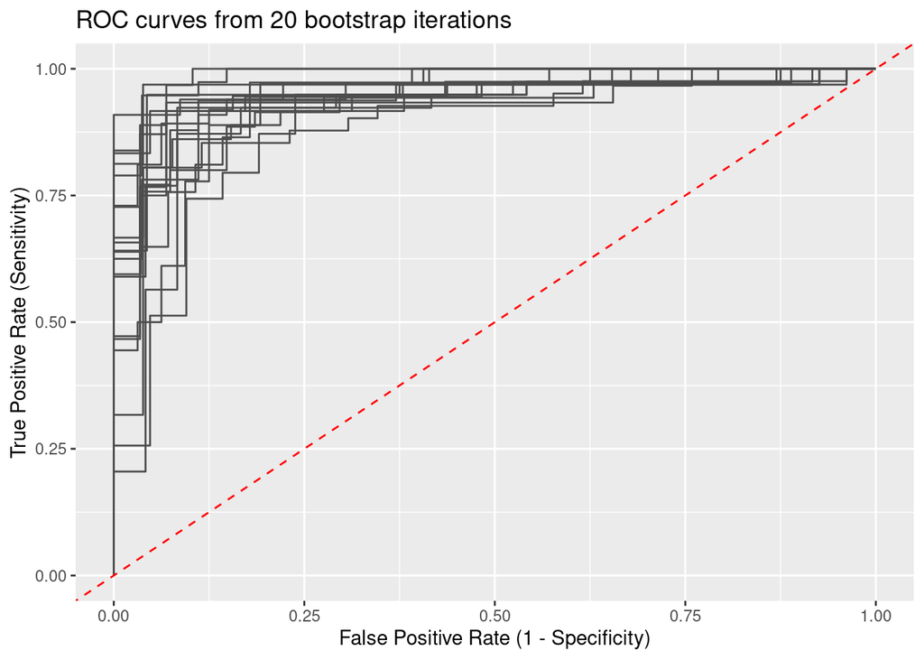

Receiver operating characteristic (ROC) curves from a random subset of out-of-bag bootstrap iterations, illustrating the model’s ability to discriminate between vegan and omnivore status based on standardized log2(metabolite) levels. Each curve corresponds to an elastic net model trained on a bootstrap resample and evaluated on the subjects not included in that iteration (i.e., out-of-bag samples). The curve plots the true positive rate (sensitivity) against the false positive rate (1 – specificity) across thresholds of predicted vegan probability. The area under the curve (AUC) quantifies overall discriminatory performance, with values closer to 1 indicating stronger separation between groups.

```r
elanet_metabolit_all$plot
```

### 5.3.3 Estimated coefficients

**Open code**

```r
elanet_metabolit_all$betas
## 34 x 1 sparse Matrix of class "dgCMatrix"
##                                 s0
## (Intercept)             0.51654945
## formate                -0.23781875
## tryptophan              0.09514574
## phenylalanine          -0.26041520
## histidine              -0.46961530
## tyrosine               -0.40207966
## glucose                -0.06094302
## mannose                 0.09576230
## threonine              -0.29336072
## lactate                -0.03716616
## glycerol                0.40862126
## glycine                 0.89462176
## ornithine               0.15526294
## lysine                 -1.29145285
## asparagine              0.82351717
## dimethylamine           0.06858337
## 2-oxoisocaproate       -0.19919398
## citrate                 0.38672431
## glutamine               0.63824650
## pyruvate                0.06344946
## acetone                -0.14041313
## proline                 0.25009447
## acetate                 0.29136570
## alanine                 0.16148569
## 3-hydroxybutyrate       0.34663556
## ethanol                 0.19167449
## 2-propanol             -0.07389282
## 2-oxoisovalerate       -0.01538734
## 3-methyl-2-oxovalerate  0.51986873
## 3-hydroxyisobutyrate   -0.40782423
## valine                 -0.53956958
## leucine                -0.36156524
## isoleucine              0.08659878
## 2-hydroxybutyrate      -0.45713854
```

### 5.3.4 Plot of coefficients

**Open code**

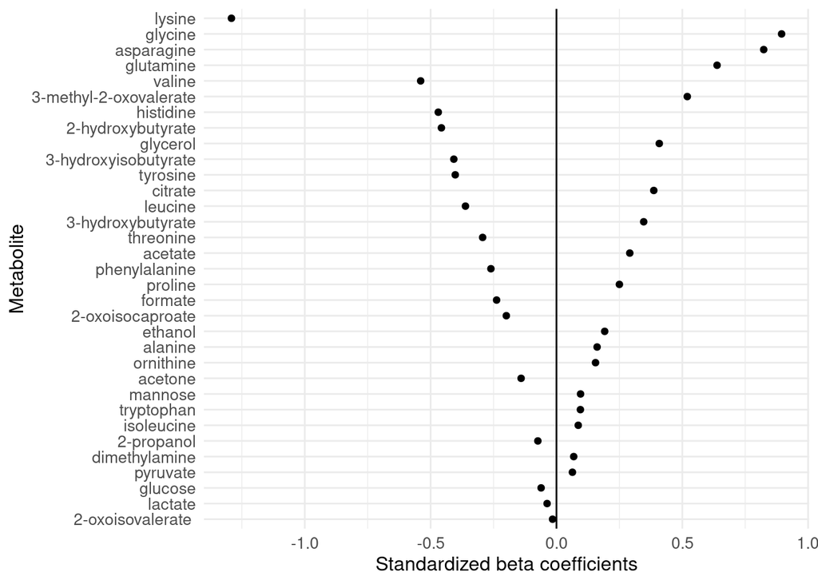

Regression coefficients from the elastic net model predicting vegan diet strategy based on log2-transformed and standardized metabolite levels. Metabolites are ordered by the magnitude of the standardized coefficients, indicating their relative importance in distinguishing between the diet groups. The sign of each coefficient indicates the direction of association with vegan diet status, with positive values indicating a higher probability of vegan status and vice versa. Metabolites whose effects were shrunk to zero are not shown.

```r
elacoef <- data.frame(
  metabolite = row.names(elanet_metabolit_all$betas),
  beta_ela = elanet_metabolit_all$betas[, 1]
) %>%
  arrange(abs(beta_ela)) %>%
  filter(abs(beta_ela) > 0,
         !grepl('Intercept', metabolite)) %>%
  mutate(metabolite = factor(metabolite, levels = metabolite)) %>%
  mutate(outcome = as.character(metabolite))

plotac <- "elanet_beta_metabolite"
path <- "gitignore/figures"

assign(plotac, elacoef %>%
  ggplot(
    aes(
      x = metabolite,
      y = beta_ela
    )
  ) +
  geom_point() +
  geom_hline(yintercept = 0, color = "black") +
  labs(
    y = "Standardized beta coefficients",
    x = "Metabolite"
  ) +
  theme_minimal() +
  coord_flip() +
  theme(
    axis.text.x = element_text(size = 10),
    axis.text.y = element_text(size = 10),
    axis.title.x = element_text(size = 12),
    axis.title.y = element_text(size = 12),
    legend.position = "bottom"
  )
)

if (file.exists(paste0(path, "/", plotac, ".svg")) == FALSE) {
    ggsave(
    path = paste0(path),
    filename = plotac,
    device = "svg",
    width = 5,
    height = 6
  )
}

get(plotac)
```

# 6 External validation

External validation was performed with an independent Czech cohort.

As a first step, we will use the previously developed and internally validated elastic net model to predict vegan status in the independent Czech cohort. The validation data will be standardized using the mean and standard deviation of each metabolite from the training cohort to ensure comparability across datasets. For each subject in the external validation cohort, we will estimate the predicted probability of being vegan using the elastic net model. This predicted probability will then be used as a variable to discriminate between the diet groups in the independent cohort.

In a 2nd step, we will look at metabolites that significantly differed between diet groups (average vegan diet effect across both countries, FDR < 0.05) estimated with linear models (one per metabolite) with training cohort. Then we will fit linear models also for external validation cohort. Effect of vegan diet on these metabolites will be shown along with 95% confidence interval for all cohorts: training Czech and Italian cohorts, but also in Czech independent (validating) cohort

## 6.1 Diet discrimination (elastic net)

#### 6.1.0.1 Get table of weights, means and SDs

**Open code**

```r
coefs_metabolom <- get_coef(
  original_data = data_analysis_metabolom,
  glmnet_model = elanet_metabolit_all)

coefs_metabolom
## # A tibble: 34 × 5
##    predictor     beta_scaled beta_OrigScale  mean     SD
##    <chr>               <dbl>          <dbl> <dbl>  <dbl>
##  1 (Intercept)        0.517         NA       NA   NA
##  2 formate           -0.238         -0.312  -19.0  0.655
##  3 tryptophan         0.0951         0.0399 -17.2  0.209
##  4 phenylalanine     -0.260         -0.0959 -16.2  0.184
##  5 histidine         -0.470         -0.177  -16.8  0.189
##  6 tyrosine          -0.402         -0.239  -16.4  0.297
##  7 glucose           -0.0609        -0.0227 -12.5  0.186
##  8 mannose            0.0958         0.0632 -18.8  0.330
##  9 threonine         -0.293         -0.143  -16.0  0.244
## 10 lactate           -0.0372        -0.0336 -14.1  0.453
## # ℹ 24 more rows
```

#### 6.1.0.2 Identify shared and missing predictors

**Open code**

```r
## Colnames in validation set
names(data_metabolites_validation)
##  [1] "NazevSouboru"           "CisloPacienta"          "SkupinaNazev"
##  [4] "SKUPINA"                "formate"                "tryptophan"
##  [7] "phenylalanine"          "histidine"              "tyrosine"
## [10] "glucose"                "mannose"                "threonine"
## [13] "lactate"                "glycerol"               "glycine"
## [16] "ornithine"              "lysine"                 "asparagine"
## [19] "dimethylamine"          "2-oxoisocaproate"       "citrate"
## [22] "glutamine"              "pyruvate"               "acetone"
## [25] "proline"                "acetate"                "alanine"
## [28] "3-hydroxybutyrate"      "ethanol"                "2-propanol"
## [31] "2-oxoisovalerate "      "3-methyl-2-oxovalerate" "3-hydroxyisobutyrate"
## [34] "valine"                 "leucine"                "isoleucine"
## [37] "2-hydroxybutyrate"

## Which are missing in the validation set
missing <- setdiff(
  coefs_metabolom$predictor[-1],
  colnames(
    data_metabolites_validation
    )
  )

missing
## character(0)

## Which are common with the validations et
common_predictors <- intersect(coefs_metabolom$predictor, colnames(data_metabolites_validation))

common_predictors
##  [1] "formate"                "tryptophan"             "phenylalanine"
##  [4] "histidine"              "tyrosine"               "glucose"
##  [7] "mannose"                "threonine"              "lactate"
## [10] "glycerol"               "glycine"                "ornithine"
## [13] "lysine"                 "asparagine"             "dimethylamine"
## [16] "2-oxoisocaproate"       "citrate"                "glutamine"
## [19] "pyruvate"               "acetone"                "proline"
## [22] "acetate"                "alanine"                "3-hydroxybutyrate"
## [25] "ethanol"                "2-propanol"             "2-oxoisovalerate "
## [28] "3-methyl-2-oxovalerate" "3-hydroxyisobutyrate"   "valine"
## [31] "leucine"                "isoleucine"             "2-hydroxybutyrate"
```

#### 6.1.0.3 Standardize data in validation set

**Open code**

```r
data_metabolites_validation_pred <- data_metabolites_validation %>%
  dplyr::mutate(
    vegan = if_else(
      SKUPINA == 1, 1, 0
    )
  ) %>%
  dplyr::select(
    vegan,
    dplyr::all_of(common_predictors)
  ) %>%
  dplyr::mutate(
    across(
      .cols = -vegan,
      .fns = trans_metabolite
      )
    ) %>%
  dplyr::mutate(
    across(
      .cols = -vegan,
      .fns = ~ .
      - coefs_metabolom$mean[
        match(
          cur_column(),
          coefs_metabolom$predictor
          )
        ]
      )
    ) %>%
  dplyr::mutate(
    across(
      .cols = -vegan,
      .fns = ~ .
      / coefs_metabolom$SD[
        match(
          cur_column(),
          coefs_metabolom$predictor
          )
        ]
      )
    )

data_metabolites_validation_pred %>% names()
##  [1] "vegan"                  "formate"                "tryptophan"
##  [4] "phenylalanine"          "histidine"              "tyrosine"
##  [7] "glucose"                "mannose"                "threonine"
## [10] "lactate"                "glycerol"               "glycine"
## [13] "ornithine"              "lysine"                 "asparagine"
## [16] "dimethylamine"          "2-oxoisocaproate"       "citrate"
## [19] "glutamine"              "pyruvate"               "acetone"
## [22] "proline"                "acetate"                "alanine"
## [25] "3-hydroxybutyrate"      "ethanol"                "2-propanol"
## [28] "2-oxoisovalerate "      "3-methyl-2-oxovalerate" "3-hydroxyisobutyrate"
## [31] "valine"                 "leucine"                "isoleucine"
## [34] "2-hydroxybutyrate"
```

#### 6.1.0.4 Get predicted value

**Open code**

```r
elanet_metabolit_all$fit
##
## Call:  glmnet::glmnet(x = original_predictors, y = original_outcome,      family = family, alpha = optim_par$alpha[1], lambda = optim_par$lamb_1se[1],      standardize = standardize)
##
##   Df  %Dev  Lambda
## 1 33 60.94 0.02731
newx <- as.matrix(data_metabolites_validation_pred[,-1])

tr <- data_metabolites_validation_pred %>%
  dplyr::mutate(
    predicted_logit = as.numeric(
      predict(
        elanet_metabolit_all$fit,
        newx = newx
        )
      )
    ) %>%
  dplyr::mutate(
    predicted = inv_logit(predicted_logit)
  )
```

### 6.1.1 Result of external validation

#### 6.1.1.1 ROC curve

**Open code**

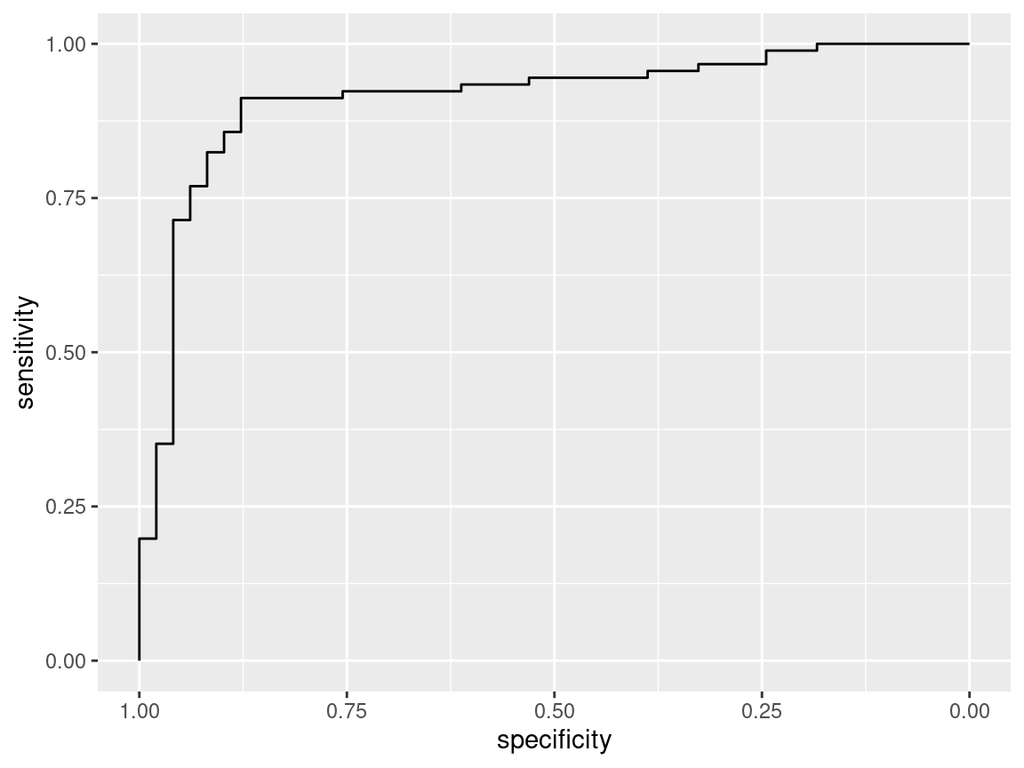

```r
roc_metabolite <- pROC::roc(
  vegan ~ predicted_logit,
  data = tr,
  direction = "<",
  levels = c(0, 1),
  ci = TRUE
)

roc_metabolite
##
## Call:
## roc.formula(formula = vegan ~ predicted_logit, data = tr, direction = "<",     levels = c(0, 1), ci = TRUE)
##
## Data: predicted_logit in 49 controls (vegan 0) < 91 cases (vegan 1).
## Area under the curve: 0.9123
## 95% CI: 0.8588-0.9658 (DeLong)

plotac <- "roc_metabolite_pl"
path <- "gitignore/figures"

assign(plotac, ggroc(roc_metabolite))
get(plotac)
```

**Open code**

```r
if (file.exists(paste0(path, "/", plotac, ".svg")) == FALSE) {
  ggsave(
    path = paste0(path),
    filename = plotac,
    device = "svg",
    width = 6,
    height = 4.5
  )
}
```

#### 6.1.1.2 Table

**Open code**

```r
mod <- elanet_metabolit_all

trainAUC <- mean(mod[["valid_performances"]]$auc_resamp_test)
trainCI <- quantile(mod[["valid_performances"]]$auc_resamp_test,
  probs = c(1 / 40, 39 / 40))

res <- data.frame(
  alpha = c(mod$model_summary$alpha, rep("", 4)),
  lambda = c(round(mod$model_summary$lambda, 4), rep("", 4)),
  `performance type` = c(
 "Training set AUC",
"Out-of-sample AUC (all)",
"Out-of-sample AUC (Czech)",
"Out-of-sample AUC (Italy)",
"External validation AUC"
  ),
  `performance [95% CI]` = c(
    sprintf("%.3f [%.3f to %.3f]", trainAUC, trainCI[1], trainCI[2]),
    sprintf("%.3f [%.3f to %.3f]",
            mod$model_summary$auc_OutOfSample,
            mod$model_summary$auc_oos_CIL,
            mod$model_summary$auc_oos_CIU),
    sprintf("%.3f [%.3f to %.3f]",
            mod$country_AUC$auc_OutOfSample_CZ,
            mod$country_AUC$auc_oos_CIL_CZ,
            mod$country_AUC$auc_oos_CIU_CZ),
    sprintf("%.3f [%.3f to %.3f]",
            mod$country_AUC$auc_OutOfSample_IT,
            mod$country_AUC$auc_oos_CIL_IT,
            mod$country_AUC$auc_oos_CIU_IT),
    sprintf("%.3f [%.3f to %.3f]",
            roc_metabolite[["ci"]][2],
            roc_metabolite[["ci"]][1],
            roc_metabolite[["ci"]][3])
  )
)


kableExtra::kable(
  res %>% mutate(across(where(is.numeric), ~ round(.x, 3))),
  caption = 'Performance of the elastic‑net logistic regression model for discriminating vegan from omnivore status using log2‑transformed metabolite levels. The model was developed on the combined training data (Czech and Italian cohorts), with the optimmized `alpha` (mixing parameter) and `lambda` (penalty strength) selected via 10-fold cross-validation. Internal validation employed 500 out‑of‑bag bootstrap resamples: the out‑of‑sample AUC is the mean across resamples, and its 95 % confidence interval (CI) is given by the 2.5th and 97.5th percentiles of the bootstrap distribution. The training‑set AUC and its CI were computed analogously from the in‑bag predictions. External validation was carried out on an independent Czech cohort; the reported AUC is the point estimate on that cohort, and its 95% CI was obtained with DeLong’s method.'
)
```

Performance of the elastic‑net logistic regression model for discriminating vegan from omnivore status using log2‑transformed metabolite levels. The model was developed on the combined training data (Czech and Italian cohorts), with the optimmized `alpha` (mixing parameter) and `lambda` (penalty strength) selected via 10-fold cross-validation. Internal validation employed 500 out‑of‑bag bootstrap resamples: the out‑of‑sample AUC is the mean across resamples, and its 95 % confidence interval (CI) is given by the 2.5th and 97.5th percentiles of the bootstrap distribution. The training‑set AUC and its CI were computed analogously from the in‑bag predictions. External validation was carried out on an independent Czech cohort; the reported AUC is the point estimate on that cohort, and its 95% CI was obtained with DeLong’s method.

| alpha | lambda | performance.type | performance..95..CI. |
| --- | --- | --- | --- |
| 0 | 0.0273 | Training set AUC | 0.988 [0.970 to 1.000] |
|  |  | Out-of-sample AUC (all) | 0.949 [0.900 to 0.989] |
|  |  | Out-of-sample AUC (Czech) | 0.950 [0.883 to 1.000] |
|  |  | Out-of-sample AUC (Italy) | 0.950 [0.858 to 1.000] |
|  |  | External validation AUC | 0.912 [0.859 to 0.966] |

## 6.2 Diet effect across datasets (forest plot)

Similarly as in training data cohorts, we will fit linear model per each of the selected metabolite level ($log_{2}$ - transformed), with a single fixed effect factor of `diet`.

### 6.2.1 Linear model in validation cohort

**Open code**

```r
data_analysis_metabolom <- data_metabolites_validation %>%
  dplyr::mutate(
    Diet_VEGAN = as.numeric(
      dplyr::if_else(
        SKUPINA == 1, 1, 0
      )
    ),
    dplyr::across(
      `formate`:`2-hydroxybutyrate`, ~ trans_metabolite(.)
    )
  ) %>%
  dplyr::select(
    Diet_VEGAN,
    dplyr::everything()
  )

summary(data_analysis_metabolom[, 1:12])
##    Diet_VEGAN   NazevSouboru       CisloPacienta      SkupinaNazev
##  Min.   :0.00   Length:140         Length:140         Length:140
##  1st Qu.:0.00   Class :character   Class :character   Class :character
##  Median :1.00   Mode  :character   Mode  :character   Mode  :character
##  Mean   :0.65
##  3rd Qu.:1.00
##  Max.   :1.00
##     SKUPINA        formate         tryptophan     phenylalanine
##  Min.   :0.00   Min.   :-21.07   Min.   :-19.59   Min.   :-17.22
##  1st Qu.:0.00   1st Qu.:-18.04   1st Qu.:-16.79   1st Qu.:-15.66
##  Median :1.00   Median :-17.90   Median :-16.67   Median :-15.57
##  Mean   :0.65   Mean   :-17.93   Mean   :-16.70   Mean   :-15.56
##  3rd Qu.:1.00   3rd Qu.:-17.79   3rd Qu.:-16.57   3rd Qu.:-15.45
##  Max.   :1.00   Max.   :-17.40   Max.   :-16.14   Max.   :-14.97
##    histidine         tyrosine         glucose          mannose
##  Min.   :-18.05   Min.   :-19.05   Min.   :-15.29   Min.   :-20.47
##  1st Qu.:-16.63   1st Qu.:-15.92   1st Qu.:-12.24   1st Qu.:-17.69
##  Median :-16.48   Median :-15.77   Median :-12.14   Median :-17.56
##  Mean   :-16.47   Mean   :-15.79   Mean   :-12.16   Mean   :-17.54
##  3rd Qu.:-16.32   3rd Qu.:-15.60   3rd Qu.:-12.04   3rd Qu.:-17.35
##  Max.   :-15.75   Max.   :-15.12   Max.   :-11.77   Max.   :-16.69
```

#### 6.2.1.1 Define number of metabolites and covariates

**Open code**

```r
n_covarites <- 5
n_features <- ncol(data_analysis_metabolom) - n_covarites
```

#### 6.2.1.2 Create empty objects

**Open code**

```r
outcome <- vector('double', n_features)
log2FD_VGdiet <- vector('double', n_features)
P_VGdiet <- vector('double', n_features)
CI_L_VGdiet <- vector('double', n_features)
CI_U_VGdiet <- vector('double', n_features)
```

#### 6.2.1.3 Linear models per outcome

**Open code**

```r
for (i in 1:n_features) {
  ## define variable
  data_analysis_metabolom$outcome <- data_analysis_metabolom[, (i + n_covarites)]

  ## fit model
  model <- lm(outcome ~ Diet_VEGAN, data = data_analysis_metabolom)

  ## save results
  outcome[i] <- names(data_analysis_metabolom)[i + n_covarites]

  ## extract diet effect
  tr <- confint(model)

  CI_L_VGdiet[i] <- tr[which(row.names(tr) == "Diet_VEGAN"), ][1]
  CI_U_VGdiet[i] <- tr[which(row.names(tr) == "Diet_VEGAN"), ][2]

  log2FD_VGdiet[i] <- summary(model)$coefficients[
    which(
      names(model$coefficients) == "Diet_VEGAN"
    ), 1
  ]

  P_VGdiet[i] <- summary(model)$coefficients[
    which(
      names(model$coefficients) == "Diet_VEGAN"
    ), 4
  ]
}
```

#### 6.2.1.4 Results table

**Open code**

```r
## relevant metabolites
diet_sensitive_metabolites <- result_metabolom %>%
  filter(
    fdr_VGdiet_avg < 0.05
  ) %>%
  select(
    outcome
  )

len <- nrow(diet_sensitive_metabolites)

result_metabolom_val <- data.frame(
  outcome,
  log2FD_VGdiet, P_VGdiet,
  CI_L_VGdiet, CI_U_VGdiet
) %>%
  filter(outcome %in% diet_sensitive_metabolites$outcome)

kableExtra::kable(result_metabolom_val,
                  caption = 'Results of linear models estimating the effect of diet on metabolite levels. Only metabolites that significantly differed between diet groups in training cohorts (FDR < 0.05, average effect across both training cohorts) were included. `log2FD` denotes the estimated effects (regression coefficient), indicating how much the log2-transformed metabolite levels differ between vegans and omnivores. `P`: p-value, `fdr`: p-value adjusted for multiple comparisons, and `CI_L` and `CI_U` represent the lower and upper bounds of the 95% confidence interval, respectively. All estimates in a single row are based on a single model')
```

| outcome | log2FD_VGdiet | P_VGdiet | CI_L_VGdiet | CI_U_VGdiet |
| --- | --- | --- | --- | --- |
| formate | 0.1397995 | 0.0134426 | 0.0294080 | 0.2501911 |
| phenylalanine | -0.0239133 | 0.5569092 | -0.1042089 | 0.0563822 |
| histidine | 0.1928632 | 0.0000376 | 0.1033398 | 0.2823867 |
| tyrosine | -0.0529005 | 0.4108809 | -0.1797119 | 0.0739110 |
| glycerol | 1.0869457 | 0.0000000 | 0.7652919 | 1.4085994 |
| glycine | 0.5251078 | 0.0000000 | 0.3845024 | 0.6657132 |
| lysine | -0.0603541 | 0.3180455 | -0.1794414 | 0.0587332 |
| asparagine | 0.2260915 | 0.0000543 | 0.1187963 | 0.3333867 |
| 2-oxoisocaproate | -0.2146024 | 0.0001050 | -0.3208361 | -0.1083687 |
| citrate | 0.4309305 | 0.0000001 | 0.2809046 | 0.5809563 |
| glutamine | 0.3275636 | 0.0000000 | 0.2157616 | 0.4393657 |
| 2-oxoisovalerate | -0.1131207 | 0.1129090 | -0.2533195 | 0.0270781 |
| 3-hydroxyisobutyrate | -0.3644292 | 0.0013001 | -0.5838998 | -0.1449586 |
| valine | -0.0850854 | 0.0666411 | -0.1760896 | 0.0059189 |
| leucine | -0.0029199 | 0.9647790 | -0.1334316 | 0.1275918 |
| isoleucine | 0.1097519 | 0.1853915 | -0.0532959 | 0.2727997 |
| 2-hydroxybutyrate | -0.0803085 | 0.3548272 | -0.2513515 | 0.0907345 |

**Open code**

```r
if(file.exists('gitignore/lm_results/result_metabolom_validation.csv') == FALSE){
  write.table(result_metabolom_val,
              'gitignore/lm_results/result_metabolom_validation.csv',
              row.names = FALSE)
  }
```

### 6.2.2 Forest plot

#### 6.2.2.1 Data preparation

**Open code**

```r
## subset result tables
result_metabolom_subset <- result_metabolom %>%
  filter(outcome %in% diet_sensitive_metabolites$outcome)

result_metabolom_val_subset <- result_metabolom_val %>%
  filter(outcome %in% diet_sensitive_metabolites$outcome)

## create a data frame
data_forest <- data.frame(
  outcome = rep(diet_sensitive_metabolites$outcome, 3),
  beta = c(
    result_metabolom_subset$log2FD_VGdiet_inCZ,
    result_metabolom_subset$log2FD_VGdiet_inIT,
    result_metabolom_val_subset$log2FD_VGdiet
  ),
  lower = c(
    result_metabolom_subset$CI_L_VGdiet_inCZ,
    result_metabolom_subset$CI_L_VGdiet_inIT,
    result_metabolom_val_subset$CI_L_VGdiet
  ),
  upper = c(
    result_metabolom_subset$CI_U_VGdiet_inCZ,
    result_metabolom_subset$CI_U_VGdiet_inIT,
    result_metabolom_val_subset$CI_U_VGdiet
  ),
  dataset = c(
    rep("CZ", len),
    rep("IT", len),
    rep("Validation", len)
  )
)

validation_order <- data_forest %>%
  group_by(outcome) %>%
  summarise(beta_mean = mean(beta), .groups = "drop") %>%
  arrange(beta_mean) %>%
  pull(outcome)

up_winners <- data_forest %>%
  pivot_wider(names_from = dataset,
              values_from = c(beta, lower, upper)) %>%
  left_join(elacoef, by = 'outcome') %>%
  filter(beta_CZ > 0,
         beta_IT > 0,
         lower_Validation > 0,
         beta_ela > 0.1) %>%
  select(outcome)

down_winners <- data_forest %>%
  pivot_wider(names_from = dataset,
              values_from = c(beta, lower, upper)) %>%
  left_join(elacoef, by = 'outcome') %>%
  filter(beta_CZ < 0,
         beta_IT < 0,
         upper_Validation < 0,
         beta_ela < -0.1) %>%
  select(outcome)

winners <- as.character(c(up_winners$outcome, down_winners$outcome))

 data_forest <- data_forest %>%
  mutate(in_winner = if_else(outcome %in% winners, TRUE, FALSE, missing = FALSE)) %>%
  left_join(
    elacoef %>% select(-metabolite),
    by = 'outcome') %>%
   mutate(outcome = factor(outcome, levels = validation_order))
```

#### 6.2.2.2 Plotting

**Open code**

[figure not shown]

The forest plot illustrates the effects of a vegan diet on the levels of selected log2-transformed metabolites, along with their 95% confidence intervals, across two training cohorts (Czech and Italian) and one independent Czech cohort (validation). Green, blue, and grey points/lines represent differences in log2-transformed metabolite levels between vegans and omnivores within the Italian cohort, Czech cohort, and Czech validation cohort, respectively. Positive values suggest a higher metabolite level in vegans compared to omnivores. Only metabolites that showed significant differences between vegan and omnivorous diets in training cohorts (FDR < 0.05, average effect across both countries) were selected, and these effects were further validated in the independent cohort. The estimates for the training cohorts were obtained from a single linear model that included `Diet`, `Country`, and the interaction term `Diet x Country` as fixed-effect predictors. In the independent Czech validation cohort, `Diet` was the only fixed-effect predictor. Metabolites validated in the linear model and showing predictive power in the elastic net model (|β| > 0.1) are **bold**

```r
colors <- c("CZ" = "#150999", "IT" = "#329243", "Validation" = "grey60")

plotac <- "forest_metabolite"
path <- "gitignore/figures"

assign(
  plotac,
    ggplot(
      data_forest,
      aes(x = outcome, y = beta, ymin = lower, ymax = upper, color = dataset)) +
  geom_pointrange(position = position_dodge(width = 0.5), size = 0.5) +
  geom_hline(yintercept = 0, color = "black") +
  geom_errorbar(position = position_dodge(width = 0.5), width = 0.2) +
  scale_color_manual(values = colors) +
  labs(
    y = "Effect of vegan duration (+10y) on log2 lipid level",
    x = "Outcome",
    color = "Dataset"
  ) +
  theme_minimal() +
  coord_flip() +
  scale_x_discrete(
    labels = setNames(
      ifelse(data_forest$in_winner,
             paste0("**", data_forest$outcome, "**"),
             as.character(data_forest$outcome)
      ), data_forest$outcome
    )
  ) +
  theme(
    axis.text.x = element_text(size = 10),
    axis.text.y = ggtext::element_markdown(size = 10),
    axis.title.x = element_text(size = 12),
    axis.title.y = element_text(size = 12),
    legend.position = "bottom"
  )
)

if (file.exists(paste0(path, "/", plotac, ".svg")) == FALSE) {
  ggsave(
    path = paste0(path),
    filename = plotac,
    device = "svg",
    width = 6,
    height = 8
  )
}

get(plotac)
```

### 6.2.3 Boxplot

**Open code**

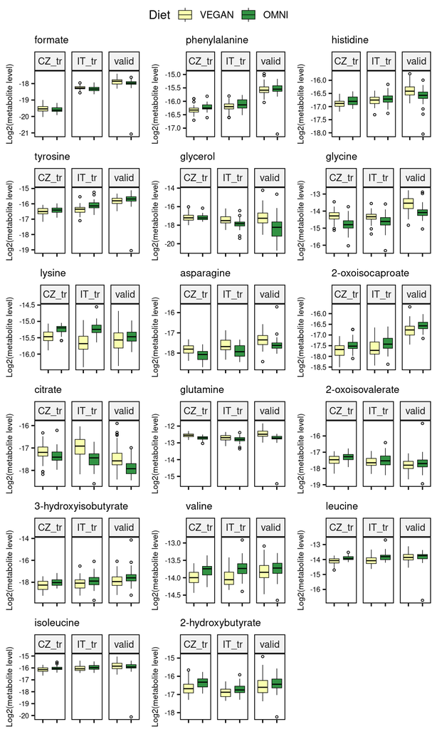

Log2-traqnsformed metabolites levels across all 3 cohorts (Czech and Italian training cohorts and an independent Czech valdiation cohort) and across dietary groups

```r
plotac <- "boxplot_metabolom"
path <- "gitignore/figures"

colo <- c('#F9FFAF','#329243')

data_merged_log2 <- data_merged %>%
  mutate(across(`formate`:`2-hydroxybutyrate`, ~ trans_metabolite(.)))

boxplot_cond <- function(variable) {

  p <- ggboxplot(data_merged_log2,
                 x = 'Diet',
                 y = variable,
                 fill = 'Diet',
                 tip.length = 0.15,
                 palette = colo,
                 outlier.shape = 1,
                 lwd = 0.25,
                 outlier.size = 0.8,
                 facet.by = 'Data',
                 title = variable,
                 ylab = 'Log2(metabolite level)') +

    theme(
      plot.title = element_text(size = 10),
      axis.title = element_text(size = 8),
      axis.text.y = element_text(size = 7),
      axis.text.x = element_blank(),
      axis.title.x = element_blank()
    )
  return(p)
}

# Plot all outcomes
plots <- map(diet_sensitive_metabolites$outcome, boxplot_cond)

# Create a matrix of plots
assign(plotac,
       ggarrange(plotlist = plots, ncol = 3, nrow = 6,  common.legend = TRUE)
       )

get(plotac)
```

**Open code**

```r
if (file.exists(paste0(path, "/", plotac, ".svg")) == FALSE) {
  ggsave(
    path = paste0(path),
    filename = plotac,
    device = "svg",
    width = 6,
    height = 10
  )
}
```